# Self Ogranizing Maps

This notebook was created by Camille-Amaury JUGE, in order to better understand Self Organizing Maps (SOM) principles and how they work.

(it follows the exercices proposed by Hadelin de Ponteves on Udemy : https://www.udemy.com/course/le-deep-learning-de-a-a-z/)

## Imports

```python
import numpy as np
import pandas as pd
from minisom import MiniSom
import matplotlib.pyplot as plt
from pylab import rcParams, bone, pcolor, colorbar, plot, show
rcParams['figure.figsize'] = 16, 10
# scikit learn
from sklearn.preprocessing import MinMaxScaler, StandardScaler
# keras
import keras
from keras.layers import Dense
from keras.models import Sequential
```

## preprocessing

The dataset represents customers of a bank and if they've been approved to possess a credit card. We want to isolate fraudsters from normal customers. This will serve as an indicator for manual processing.

The dataset has been anonymised, then we don't have clear variables names and individuals name.

```python
df = pd.read_csv("Credit_card_Applications.csv")
df.head()
```

|  | CustomerID | A1 | A2 | A3 | A4 | A5 | A6 | A7 | A8 | A9 | A10 | A11 | A12 | A13 | A14 | Class |
| --- | --- | --- | --- | --- | --- | --- | --- | --- | --- | --- | --- | --- | --- | --- | --- | --- |
| 0 | 15776156 | 1 | 22.08 | 11.46 | 2 | 4 | 4 | 1.585 | 0 | 0 | 0 | 1 | 2 | 100 | 1213 | 0 |
| 1 | 15739548 | 0 | 22.67 | 7.00 | 2 | 8 | 4 | 0.165 | 0 | 0 | 0 | 0 | 2 | 160 | 1 | 0 |
| 2 | 15662854 | 0 | 29.58 | 1.75 | 1 | 4 | 4 | 1.250 | 0 | 0 | 0 | 1 | 2 | 280 | 1 | 0 |
| 3 | 15687688 | 0 | 21.67 | 11.50 | 1 | 5 | 3 | 0.000 | 1 | 1 | 11 | 1 | 2 | 0 | 1 | 1 |
| 4 | 15715750 | 1 | 20.17 | 8.17 | 2 | 6 | 4 | 1.960 | 1 | 1 | 14 | 0 | 2 | 60 | 159 | 1 |

```python
df.describe().transpose().round(2)
```

|  | count | mean | std | min | 25% | 50% | 75% | max |
| --- | --- | --- | --- | --- | --- | --- | --- | --- |
| CustomerID | 690.0 | 15690470.54 | 71506.47 | 15565714.00 | 15631687.00 | 15690161.00 | 15751896.00 | 15815443.00 |
| A1 | 690.0 | 0.68 | 0.47 | 0.00 | 0.00 | 1.00 | 1.00 | 1.00 |
| A2 | 690.0 | 31.57 | 11.85 | 13.75 | 22.67 | 28.62 | 37.71 | 80.25 |
| A3 | 690.0 | 4.76 | 4.98 | 0.00 | 1.00 | 2.75 | 7.21 | 28.00 |
| A4 | 690.0 | 1.77 | 0.43 | 1.00 | 2.00 | 2.00 | 2.00 | 3.00 |
| A5 | 690.0 | 7.37 | 3.68 | 1.00 | 4.00 | 8.00 | 10.00 | 14.00 |
| A6 | 690.0 | 4.69 | 1.99 | 1.00 | 4.00 | 4.00 | 5.00 | 9.00 |
| A7 | 690.0 | 2.22 | 3.35 | 0.00 | 0.16 | 1.00 | 2.62 | 28.50 |
| A8 | 690.0 | 0.52 | 0.50 | 0.00 | 0.00 | 1.00 | 1.00 | 1.00 |
| A9 | 690.0 | 0.43 | 0.50 | 0.00 | 0.00 | 0.00 | 1.00 | 1.00 |
| A10 | 690.0 | 2.40 | 4.86 | 0.00 | 0.00 | 0.00 | 3.00 | 67.00 |
| A11 | 690.0 | 0.46 | 0.50 | 0.00 | 0.00 | 0.00 | 1.00 | 1.00 |
| A12 | 690.0 | 1.93 | 0.30 | 1.00 | 2.00 | 2.00 | 2.00 | 3.00 |
| A13 | 690.0 | 184.01 | 172.16 | 0.00 | 80.00 | 160.00 | 272.00 | 2000.00 |
| A14 | 690.0 | 1018.39 | 5210.10 | 1.00 | 1.00 | 6.00 | 396.50 | 100001.00 |
| Class | 690.0 | 0.44 | 0.50 | 0.00 | 0.00 | 0.00 | 1.00 | 1.00 |

```python
df.dtypes
```

```
CustomerID      int64
A1              int64
A2            float64
A3            float64
A4              int64
A5              int64
A6              int64
A7            float64
A8              int64
A9              int64
A10             int64
A11             int64
A12             int64
A13             int64
A14             int64
Class           int64
dtype: object
```

The dataset represents 690 anonym customers, since the amount of data is really low, we will try to group those customers by proximity using SOMs. We expect to have a suspicious group.

Since Fraud is a behavior which acts differently than normality, we expect fraudsters neurons to be apart from the generality. Then we will use a distance called "MID".

Firstly, we are going to separate the classes column (validated or refused) from the rest.

```python
X = df.iloc[:,:-1].values
Y = df.iloc[:,-1].values
```

Since it's a non-supervised model, our Y doesn't represent the Label but will help us in interpretation.

Then, we are going to scale our variable.

```python
scaler = MinMaxScaler()
```

```python
X = scaler.fit_transform(X)
```

## Model

### SOMs

we will :

- create a 10 * 10 SOM.
- Instanciate the weight randomly.

```python
_map_size = (10,10)
_iteration = 100
```

```python
model_som = MiniSom(x=_map_size[0], y=_map_size[1], input_len=X.shape[1])
```

```python
model_som.random_weights_init(X)
```

```python
model_som.train_random(X, num_iteration=_iteration)
```

### Visualization

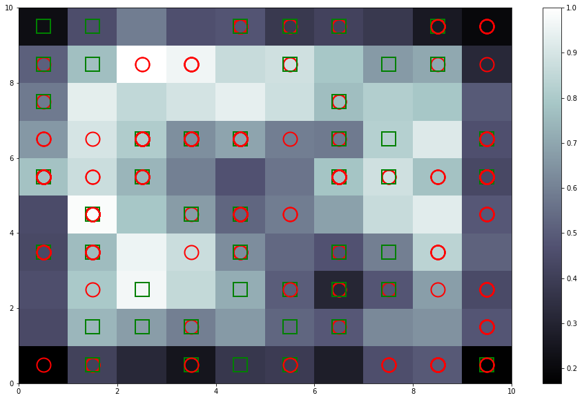

```python
bone()
pcolor(model_som.distance_map().T)
colorbar()

markers = ["o", "s"]
colors = ["r", "g"]

for i, x in enumerate(X):
    # get the winner neurons of the line (x)
    winner = model_som.winner(x)
    plot(winner[0] + 0.5, winner[1] + 0.5, markers[Y[i]],
        markeredgecolor = colors[Y[i]],
         markerfacecolor = "None",
        markersize=20,
        markeredgewidth=2)
show()
```

We will get the coordinates of White winners (supposed fraudsters) neurons here :

```python
mappings = model_som.win_map(X)
fraudsters = np.concatenate((mappings[(1,4)], mappings[(2,2)],
                             mappings[(3,8)], mappings[(3,8)]),
                           axis = 0)
```

```python
fraudsters = pd.DataFrame(scaler.inverse_transform(fraudsters))
```

```python
fraudsters.iloc[:, 0] = fraudsters.iloc[:, 0].astype(int)
```

```python
fraudsters.head(5)
```

|  | 0 | 1 | 2 | 3 | 4 | 5 | 6 | 7 | 8 | 9 | 10 | 11 | 12 | 13 | 14 |
| --- | --- | --- | --- | --- | --- | --- | --- | --- | --- | --- | --- | --- | --- | --- | --- |
| 0 | 15605791 | 1.0 | 19.50 | 9.585 | 2.0 | 6.0 | 4.0 | 0.79 | 0.0 | 0.0 | 0.0 | 0.0 | 2.0 | 80.0 | 351.0 |
| 1 | 15709459 | 1.0 | 29.42 | 1.250 | 2.0 | 9.0 | 4.0 | 1.75 | 0.0 | 0.0 | 0.0 | 0.0 | 2.0 | 200.0 | 1.0 |
| 2 | 15565714 | 1.0 | 42.75 | 4.085 | 2.0 | 6.0 | 4.0 | 0.04 | 0.0 | 0.0 | 0.0 | 0.0 | 2.0 | 108.0 | 101.0 |
| 3 | 15655464 | 1.0 | 21.25 | 1.500 | 2.0 | 9.0 | 4.0 | 1.50 | 0.0 | 0.0 | 0.0 | 0.0 | 2.0 | 150.0 | 9.0 |
| 4 | 15698271 | 1.0 | 28.92 | 0.375 | 2.0 | 8.0 | 4.0 | 0.29 | 0.0 | 0.0 | 0.0 | 0.0 | 2.0 | 220.0 | 141.0 |

```python
print("{} fraudsters detected".format(fraudsters.shape[0]))
```

```
52 fraudsters detected
```

Then we have the supposed fraudsters.

Now, we can go further. We want to evaluate a scoring method that will give the probability of a customer to be a fraudster or not. For that purpose, we will use an ANN.

```python
X_ann = df.iloc[:, 1:]
```

```python
Y_ann = np.zeros(X_ann.shape[0])
for i in range(X_ann.shape[0]):
    for j in range(fraudsters.shape[0]):
        if df.iloc[i, 0] == fraudsters.iloc[j,0]:
            Y_ann[i] = 1
            break
```

```python
scaler_ann = StandardScaler()
```

```python
X_ann = scaler_ann.fit_transform(X_ann)
```

```python
def model():
    model = Sequential()
    model.add(Dense(units=10, kernel_initializer="uniform", activation="relu",
                   input_dim=15))
    model.add(Dense(units=1, kernel_initializer="uniform", activation="sigmoid"))

    model.compile(optimizer="adam", loss="binary_crossentropy",
                  metrics=["accuracy"])
    return model
```

```python
model = model()
```

```python
model.fit(X_ann, Y_ann, epochs = 10)
```

```
<keras.callbacks.callbacks.History at 0x1ac7a5ba2c8>
```

```python
y_pred = model.predict(X_ann)
```

since we had a little amount of data, we use the training set as the test set (else we would proceed as always with separate dataset).

```python
y_pred = np.concatenate((df.iloc[:,0:1], y_pred), axis=1)
```

```python
y_pred
```

```
array([[1.57761560e+07, 1.90363005e-01],
       [1.57395480e+07, 1.87461764e-01],
       [1.56628540e+07, 7.42477700e-02],
       ...,
       [1.56754500e+07, 2.36789078e-01],
       [1.57764940e+07, 8.47537890e-02],
       [1.55924120e+07, 3.31025958e-01]])
```

```python
y_pred = pd.DataFrame(y_pred[y_pred[:,1].argsort()])
```

```python
y_pred.head(-5)
```

|  | 0 | 1 |
| --- | --- | --- |
| 0 | 15799785.0 | 0.006270 |
| 1 | 15621423.0 | 0.007345 |
| 2 | 15654859.0 | 0.008494 |
| 3 | 15725028.0 | 0.011103 |
| 4 | 15585855.0 | 0.013270 |
| ... | ... | ... |
| 680 | 15736510.0 | 0.390481 |
| 681 | 15666096.0 | 0.392659 |
| 682 | 15692408.0 | 0.402506 |
| 683 | 15636626.0 | 0.404141 |
| 684 | 15711249.0 | 0.411374 |

685 rows × 2 columns